# Coursera Bellabeat

Trude

10/1/2021

## Introduction

Bellabeat is a high-tech company that manufactures health-focused smart products.Their product offerings range from the **Bellabeat app**, the **Leaf** wellness tracker (necklace/bracelet/clip), the wellness watch **Time**, the **Spring** water bottle, and a a subscription-based **membership program**. All their physical product connect to the app to track activity, sleep, and stress, hydration levels, and more, to provide users with insights into their overall daily wellness.

This small but successful company aims to become a larger player in the global smart device market, and use the findings from this analysis to guide their marketing strategy.

## Business Task

To gain insights into how consumers are using their smart devices by analyzing smart device usage trends, the company wants to identify new growth opportunities to become a larger player in the global smart device market.

Some questions to consider:

- What are some trends in smart device usage?
- How could these trends apply to Bellabeat customers?
- How could these trends help influence the Bellabeat marketing strategy?

Let’s get started…

## Installing and loading common packages and libraries

Setting up my environment by loading the following packages: tidyverse, here, skimr, janitor for cleaning the data and for organizing the data dplyr to filter the data, and ggplot2 for visualization.

- install.packages(‘tidyverse’)
- install.packages(‘here’)
- install.packages(‘skimr’)
- install.packages(‘janitor’)
- install.packages(‘dplyr’)
- install.packages(‘ggplot2’)

```r
library(tidyverse)
library(here)
library(skimr)
library(janitor)
library(dplyr)
library(ggplot2)
```

## Loading the CSV files

The data source I used is : [FitBit Fitness Tracker Data](https://www.kaggle.com/arashnic/fitbit) The datasets in this source were generated by respondents to a distributed survey via Amazon Mechanical Turk between 03.12.2016-05.12.2016. Thirty eligible Fitbit users consented to the submission of personal tracker data, including minute-level output for physical activity, heart rate, and sleep monitoring. Variation between output represents the use of different types of Fitbit trackers and individual tracking behaviors/preferences (Möbius, 2016).

A few things to note here are that the data source is from 2016, so not very current. It mentions different types of users but doesn’t specify how different these types of users were. Also, the sample size is very small, and there’s no data on hydration levels.

Let’s do a ROCCC analysis: **Reliable**: Kaggle gives it a usability ranking of 10. **Original**: It’s not the original source, it was surveyed via Amazon Mechanical Turk. **Current**, It was surveyed between 03.12.2016-05.12.2016, so it’s not very current. **Comprehensive**: It does not seem comprehensive because it might not contain all critical information needed to answer the question or find the solution. **Cited** The source is cited, This survey has been created by Amazon Mechanical Turk so it Is it part of a credible organization and it has been refreshed recently. Other sources might be needed here.

Further examination of the data source, reveals there are many csv files in the data source. I will be quickly scanning them to determine which are useful and relevant. I notice calories, daily activity, intensities, sleep, weight, steps, and heart rate.

On to creating the following data frames:

- daily_activity
- sleep_day
- weight_log
- daily_calories
- daily_intensities
- daily_steps

```r
daily_activity <- read.csv("dailyActivity_merged.csv")
sleep_day <- read.csv("sleepDay_merged.csv")
weight_log <- read.csv("weightLogInfo_merged.csv")
daily_calories <- read.csv("dailyCalories_merged.csv")
daily_intensities <- read.csv("dailyIntensities_merged.csv")
daily_steps <- read.csv("dailySteps_merged.csv")
```

# DATA CLEANING AND MANIPULATION

## Exploring the Tables

Now it is time to examine what is in the tables. I will use the head() and colnames() function for exploring each table.

#### ACTIVITY

Taking a look at the daily_activity data.

With the head() function:

```
##           Id ActivityDate TotalSteps TotalDistance TrackerDistance
## 1 1503960366    4/12/2016      13162          8.50            8.50
## 2 1503960366    4/13/2016      10735          6.97            6.97
## 3 1503960366    4/14/2016      10460          6.74            6.74
## 4 1503960366    4/15/2016       9762          6.28            6.28
## 5 1503960366    4/16/2016      12669          8.16            8.16
## 6 1503960366    4/17/2016       9705          6.48            6.48
##   LoggedActivitiesDistance VeryActiveDistance ModeratelyActiveDistance
## 1                        0               1.88                     0.55
## 2                        0               1.57                     0.69
## 3                        0               2.44                     0.40
## 4                        0               2.14                     1.26
## 5                        0               2.71                     0.41
## 6                        0               3.19                     0.78
##   LightActiveDistance SedentaryActiveDistance VeryActiveMinutes
## 1                6.06                       0                25
## 2                4.71                       0                21
## 3                3.91                       0                30
## 4                2.83                       0                29
## 5                5.04                       0                36
## 6                2.51                       0                38
##   FairlyActiveMinutes LightlyActiveMinutes SedentaryMinutes Calories
## 1                  13                  328              728     1985
## 2                  19                  217              776     1797
## 3                  11                  181             1218     1776
## 4                  34                  209              726     1745
## 5                  10                  221              773     1863
## 6                  20                  164              539     1728
```

Using the colnames() function:

```
##  [1] "Id"                       "ActivityDate"
##  [3] "TotalSteps"               "TotalDistance"
##  [5] "TrackerDistance"          "LoggedActivitiesDistance"
##  [7] "VeryActiveDistance"       "ModeratelyActiveDistance"
##  [9] "LightActiveDistance"      "SedentaryActiveDistance"
## [11] "VeryActiveMinutes"        "FairlyActiveMinutes"
## [13] "LightlyActiveMinutes"     "SedentaryMinutes"
## [15] "Calories"
```

#### SLEEP

Taking a look at the sleep_day data

With the head() function:

```
##           Id              SleepDay TotalSleepRecords TotalMinutesAsleep
## 1 1503960366 4/12/2016 12:00:00 AM                 1                327
## 2 1503960366 4/13/2016 12:00:00 AM                 2                384
## 3 1503960366 4/15/2016 12:00:00 AM                 1                412
## 4 1503960366 4/16/2016 12:00:00 AM                 2                340
## 5 1503960366 4/17/2016 12:00:00 AM                 1                700
## 6 1503960366 4/19/2016 12:00:00 AM                 1                304
##   TotalTimeInBed
## 1            346
## 2            407
## 3            442
## 4            367
## 5            712
## 6            320
```

Using the colnames() function:

```
## [1] "Id"                 "SleepDay"           "TotalSleepRecords"
## [4] "TotalMinutesAsleep" "TotalTimeInBed"
```

#### WEIGHT

Taking a look at the weight_log data.

With the head() function:

```
##           Id                  Date WeightKg WeightPounds Fat   BMI
## 1 1503960366  5/2/2016 11:59:59 PM     52.6     115.9631  22 22.65
## 2 1503960366  5/3/2016 11:59:59 PM     52.6     115.9631  NA 22.65
## 3 1927972279  4/13/2016 1:08:52 AM    133.5     294.3171  NA 47.54
## 4 2873212765 4/21/2016 11:59:59 PM     56.7     125.0021  NA 21.45
## 5 2873212765 5/12/2016 11:59:59 PM     57.3     126.3249  NA 21.69
## 6 4319703577 4/17/2016 11:59:59 PM     72.4     159.6147  25 27.45
##   IsManualReport        LogId
## 1           True 1.462234e+12
## 2           True 1.462320e+12
## 3          False 1.460510e+12
## 4           True 1.461283e+12
## 5           True 1.463098e+12
## 6           True 1.460938e+12
```

Using the colnames() function:

```
## [1] "Id"             "Date"           "WeightKg"       "WeightPounds"
## [5] "Fat"            "BMI"            "IsManualReport" "LogId"
```

#### CALORIES

Taking a look at the daily_calories data.

With the head() function:

```
##           Id ActivityDay Calories
## 1 1503960366   4/12/2016     1985
## 2 1503960366   4/13/2016     1797
## 3 1503960366   4/14/2016     1776
## 4 1503960366   4/15/2016     1745
## 5 1503960366   4/16/2016     1863
## 6 1503960366   4/17/2016     1728
```

Using the colnames() function:

```
## [1] "Id"          "ActivityDay" "Calories"
```

#### INTENSITIES

Taking a look at the daily_intensities data.

With the head() function:

```
##           Id ActivityDay SedentaryMinutes LightlyActiveMinutes
## 1 1503960366   4/12/2016              728                  328
## 2 1503960366   4/13/2016              776                  217
## 3 1503960366   4/14/2016             1218                  181
## 4 1503960366   4/15/2016              726                  209
## 5 1503960366   4/16/2016              773                  221
## 6 1503960366   4/17/2016              539                  164
##   FairlyActiveMinutes VeryActiveMinutes SedentaryActiveDistance
## 1                  13                25                       0
## 2                  19                21                       0
## 3                  11                30                       0
## 4                  34                29                       0
## 5                  10                36                       0
## 6                  20                38                       0
##   LightActiveDistance ModeratelyActiveDistance VeryActiveDistance
## 1                6.06                     0.55               1.88
## 2                4.71                     0.69               1.57
## 3                3.91                     0.40               2.44
## 4                2.83                     1.26               2.14
## 5                5.04                     0.41               2.71
## 6                2.51                     0.78               3.19
```

Using the colnames() function:

```
##  [1] "Id"                       "ActivityDay"
##  [3] "SedentaryMinutes"         "LightlyActiveMinutes"
##  [5] "FairlyActiveMinutes"      "VeryActiveMinutes"
##  [7] "SedentaryActiveDistance"  "LightActiveDistance"
##  [9] "ModeratelyActiveDistance" "VeryActiveDistance"
```

#### STEPS

Taking a look at the daily_steps data.

With the head() function:

```
##           Id ActivityDay StepTotal
## 1 1503960366   4/12/2016     13162
## 2 1503960366   4/13/2016     10735
## 3 1503960366   4/14/2016     10460
## 4 1503960366   4/15/2016      9762
## 5 1503960366   4/16/2016     12669
## 6 1503960366   4/17/2016      9705
```

Using the colnames() function:

```
## [1] "Id"          "ActivityDay" "StepTotal"
```

## DATA ANALYSIS

#### Some Assumptions

Note that all datasets have the ‘Id’ field, which can be used to merge the data sets, if needed.

The daily activity_table already contains the data for daily_calories, daily_intensities, and daily_steps data. The number of observations in these tables are exactly the same, so I will just focus on the following tables:

- daily_activity,
- sleep,
- weight_log

#### Some Quick Summary Statistics

Let’s check how many unique participants there are in each data frame with the distinct() function:

daily_activity dataset:

```
## [1] 33
```

sleep_day dataset:

```
## [1] 24
```

weight_log dataset:

```
## [1] 8
```

The daily_activity dataset has 33 unique participants, yet only 30 people participated in the study.

The sleep and weight tables have fewer unique participants. When looking at the weight_log table, I noticed that the table has a column named “IsManualReport”, from which I conclude that this data is inputted manually and maybe explains this low number. For sleep I will need to investigate this more.

These findings will have an effect on the accuracy of the outcome of the analysis.

I’d like to know many observation there are in each dataframe. Let’s find out using the nrow() function:

daily_activity dataset:

```
## [1] 940
```

sleep_day dataset:

```
## [1] 413
```

weight_log dataset:

```
## [1] 67
```

The sleep_day table has fewer observations than the daily-activity data.

The weight_log table has only 67 observations. I will assume that this data is inputted manually to explain the low number of observations.

Note that all these findings will also have an effect on the reliability of the outcome of the analysis.

## Summary statistics

Now let’s do some quick summary statistics for each data frame:

For the daily_activity dataframe:

```
##    TotalSteps    TotalDistance    SedentaryMinutes
##  Min.   :    0   Min.   : 0.000   Min.   :   0.0
##  1st Qu.: 3790   1st Qu.: 2.620   1st Qu.: 729.8
##  Median : 7406   Median : 5.245   Median :1057.5
##  Mean   : 7638   Mean   : 5.490   Mean   : 991.2
##  3rd Qu.:10727   3rd Qu.: 7.713   3rd Qu.:1229.5
##  Max.   :36019   Max.   :28.030   Max.   :1440.0
```

For the sleep_day dataframe:

```
##  TotalSleepRecords TotalMinutesAsleep TotalTimeInBed
##  Min.   :1.000     Min.   : 58.0      Min.   : 61.0
##  1st Qu.:1.000     1st Qu.:361.0      1st Qu.:403.0
##  Median :1.000     Median :433.0      Median :463.0
##  Mean   :1.119     Mean   :419.5      Mean   :458.6
##  3rd Qu.:1.000     3rd Qu.:490.0      3rd Qu.:526.0
##  Max.   :3.000     Max.   :796.0      Max.   :961.0
```

Here, the average hours of actual sleep is 7 (419.5 minutes) and the average time in bed is 7.6 hours. According to the CDC, adults between 18 and 60 should get 7 hours of sleep per day.

For the weight_log dataframe:

```
##   WeightPounds        Fat             BMI
##  Min.   :116.0   Min.   :22.00   Min.   :21.45
##  1st Qu.:135.4   1st Qu.:22.75   1st Qu.:23.96
##  Median :137.8   Median :23.50   Median :24.39
##  Mean   :158.8   Mean   :23.50   Mean   :25.19
##  3rd Qu.:187.5   3rd Qu.:24.25   3rd Qu.:25.56
##  Max.   :294.3   Max.   :25.00   Max.   :47.54
##                  NA's   :65
```

The average weight of the participants was 158lbs, but we don’t know if the participants were male or female, their ages, and in addition to the low sample size, we can’t really derive any information from this number. Just to compare, according to the CDC, the measured average weight for adults aged 20 and over for men is 199.8 pounds and for women is 170.8 pounds.

The average body fat percentage was 23.5 and the average number for BMI was 25.19. According to Medical News Today, a body fat percentage of 23.5 is either fair, poor, or dangerously high depending on the sex and age group, and “A BMI between 25 and 29.9 indicates that a person has overweight”.

A good goal here is to lose weight, lower the body fat percentage and obtaining a lower BMI.

## DATA VISUALIZATION

From looking at the statistics I will investigate the following:

- The relationship between activity, steps, distance and calories
- The relationship between total steps and sedentary minutes
- The relationship between minutes asleep vs time in bed
- The relationship between activity and sleep
- The relationship between activity and weight

Plotting a few explorations now.

### Activity vs. Calories

What is the relationship between the level of activity and the calories burnt? I would expect that the more active you are, the more calories you burn, but let’s find out to be certain:

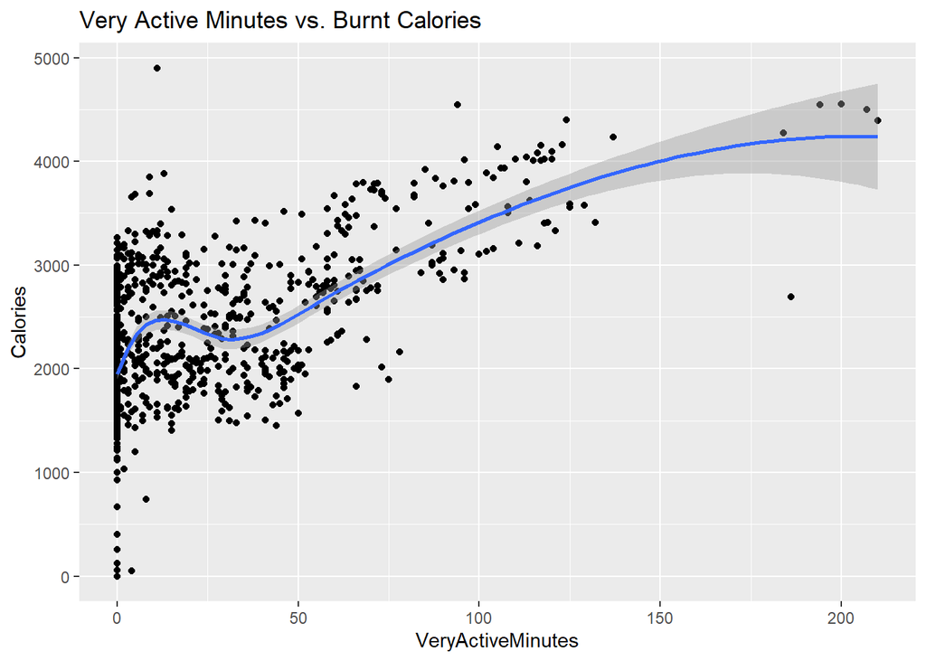

Let’s calculate the Correlation coefficients for **very active minutes vs calories**:

```
## [1] 0.6158383
```

That’s a moderate positive relationship. This means that the more active the participant was, the more calories they burned.

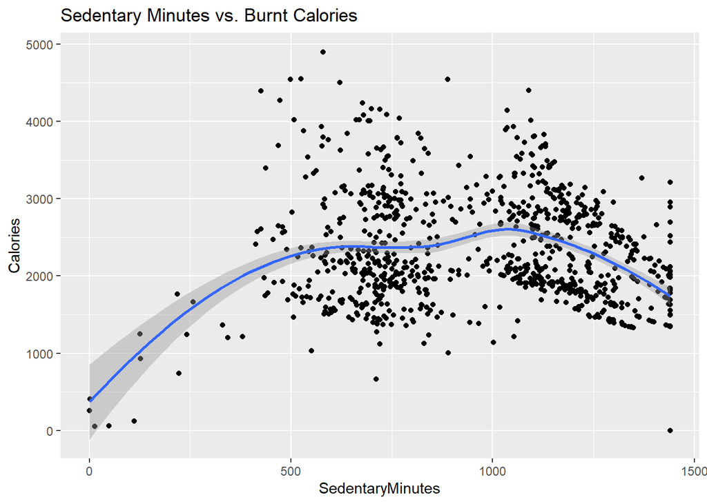

For sedentary minutes vs calories:

```
## [1] -0.106973
```

For sedentary minutes per day and calories burnt per day there is no correlation at all. This means that the amount of time you are non-active has no effect on the amount of calories you burn. For less active users, they need to become more active to start burning more calories.

### Total Steps vs Calories

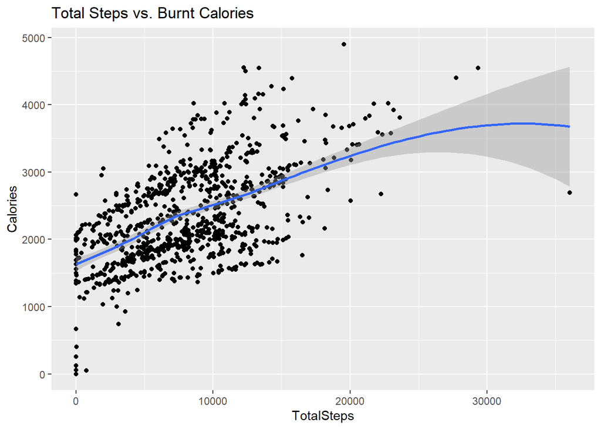

Let’s calculate the correlation coefficient now:

```
## [1] 0.5915681
```

This means that there is a moderate positive relationship between total steps taken per day and calories burnt.

### Total Distance vs Calories

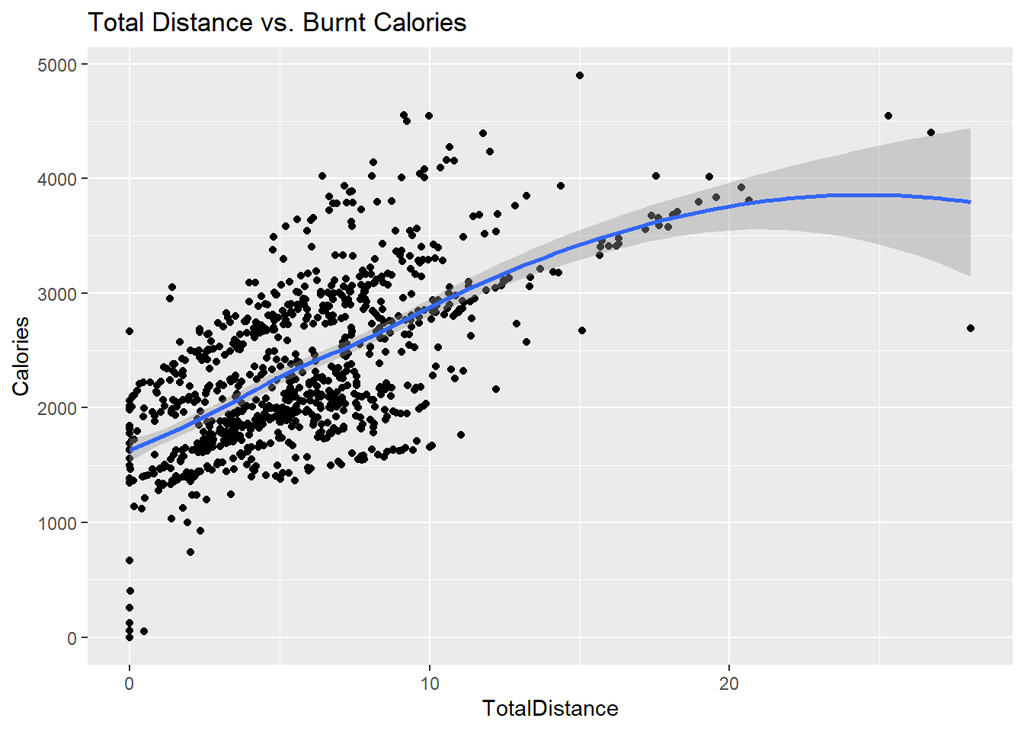

Let’s calculate the correlation coefficient now:

```
## [1] 0.6449619
```

That’s also a moderate positive correlation. The more distance the participants covered, the more calories they burned.

If people can view how active they are, how many steps they are taking, what distance they have covered, and how many calories they burn, they are encouraged to become even more active.

### Total Steps vs Sedentary Minutes

What’s the relationship between steps taken in a day and sedentary minutes?

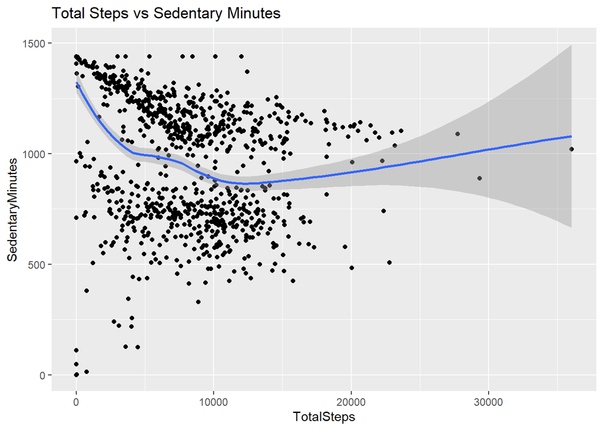

Let’s calculate the Correlation coefficient:

```
## [1] -0.3274835
```

Looks like the more steps users made the less non-active they were, and reversely, the more non-active minutes spent the less steps they took. We could position this as a way to encourage people to become more active, by just taking more steps a day.

### Minutes Asleep vs Time in Bed

Let’s find out about the relationship between minutes asleep and time in bed. I would expect this to be almost completely linear, let’s find out:

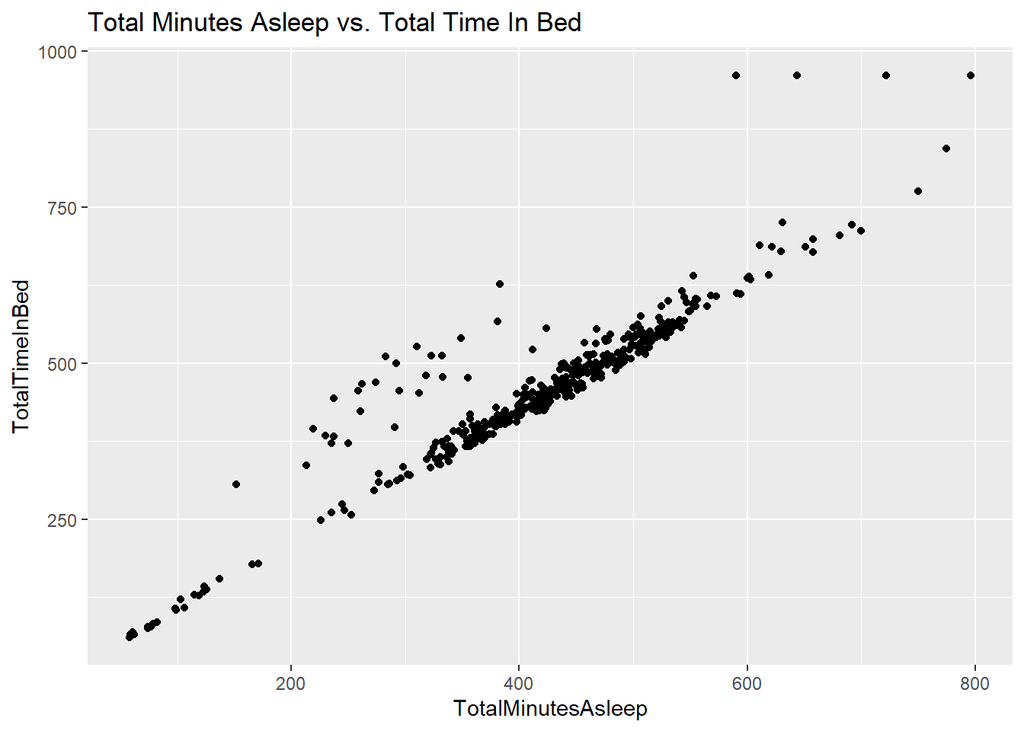

```
## [1] 0.9304575
```

Wow, very close to “1”, so there is a strong positive linear relationship, indeed, but with some outliers. This makes sense because time spent in bed is sometimes not entirely spent on sleeping. These trends show that being able to check your time in bed versus the time you actually sleep provides insights in your sleep habits.

Now I am wondering: does sleep have an effect on your activity? Are you more active if you sleep longer? I would like to explore this further.

#### Merging the sleep and activity datasets together

```r
combined_data <- merge(sleep_day, daily_activity, by="Id")
```

Using the head() function:

```
##           Id              SleepDay TotalSleepRecords TotalMinutesAsleep
## 1 1503960366 4/12/2016 12:00:00 AM                 1                327
## 2 1503960366 4/12/2016 12:00:00 AM                 1                327
## 3 1503960366 4/12/2016 12:00:00 AM                 1                327
## 4 1503960366 4/12/2016 12:00:00 AM                 1                327
## 5 1503960366 4/12/2016 12:00:00 AM                 1                327
## 6 1503960366 4/12/2016 12:00:00 AM                 1                327
##   TotalTimeInBed ActivityDate TotalSteps TotalDistance TrackerDistance
## 1            346     5/7/2016      11992          7.71            7.71
## 2            346     5/6/2016      12159          8.03            8.03
## 3            346     5/1/2016      10602          6.81            6.81
## 4            346    4/30/2016      14673          9.25            9.25
## 5            346    4/12/2016      13162          8.50            8.50
## 6            346    4/13/2016      10735          6.97            6.97
##   LoggedActivitiesDistance VeryActiveDistance ModeratelyActiveDistance
```

[output cut: 20 more lines]

Taking a look at how many participants are in this data set by using the n_distinct() function:

```
## [1] 24
```

Note that there were more participant Ids in the daily activity dataset that have been filtered out using the merge() function. Let’s do an ‘outer_join’ to keep those in the dataset using the merge() function.

```r
combined_data_2 <- merge(sleep_day, daily_activity, by="Id", all=TRUE)
head(combined_data_2)
```

```
##           Id              SleepDay TotalSleepRecords TotalMinutesAsleep
## 1 1503960366 4/12/2016 12:00:00 AM                 1                327
## 2 1503960366 4/12/2016 12:00:00 AM                 1                327
## 3 1503960366 4/12/2016 12:00:00 AM                 1                327
## 4 1503960366 4/12/2016 12:00:00 AM                 1                327
## 5 1503960366 4/12/2016 12:00:00 AM                 1                327
## 6 1503960366 4/12/2016 12:00:00 AM                 1                327
##   TotalTimeInBed ActivityDate TotalSteps TotalDistance TrackerDistance
## 1            346     5/7/2016      11992          7.71            7.71
## 2            346     5/6/2016      12159          8.03            8.03
## 3            346     5/1/2016      10602          6.81            6.81
## 4            346    4/30/2016      14673          9.25            9.25
## 5            346    4/12/2016      13162          8.50            8.50
## 6            346    4/13/2016      10735          6.97            6.97
##   LoggedActivitiesDistance VeryActiveDistance ModeratelyActiveDistance
```

[output cut: 20 more lines]

Now, let’s find out how many participants are in this new data set by using the distinct() function:

```
## [1] 33
```

Great! Now we are back at 33 values and we can start comparing activity with sleep.

### Activity vs. Sleep

Let’s explore the relationship between activity and sleep now.

We have already merged the two tables together in the previous combined_data_2 dataset, so let’s plot it:

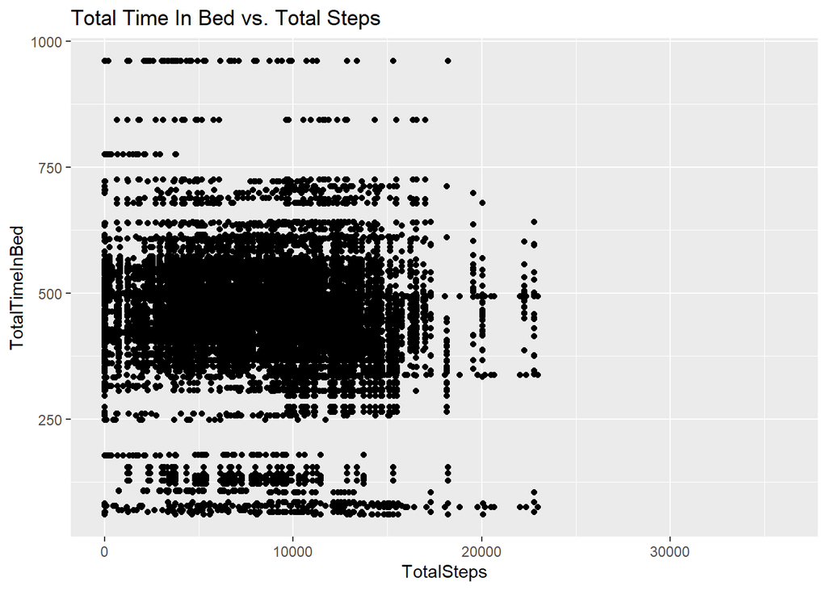

Let’s calculate the correlation coefficient to make sense of this:

```
## [1] -0.07018517
```

Looking at the graph and noting from the correlation calculation, there does not appear to be any relation between these two variables! Participants who sleep longer do not take more or fewer steps per day, and reversely, being more active does not mean that you sleep longer. Note, that his doesn’t say anything about the quality of sleep though.

Maybe the focus of the marketing strategy on how you position the product should not be too much/less on the sleep feature.

### Activity vs. Weight

I would expect that there is a relationship between the two, but let’s find out:

Merging the weight_log dataset with the daily_activity dataset:

```r
combined_data_3 <- merge(weight_log, daily_activity, by="Id", all = TRUE)
head(combined_data_3)
```

```
##           Id                 Date WeightKg WeightPounds Fat   BMI
## 1 1503960366 5/2/2016 11:59:59 PM     52.6     115.9631  22 22.65
## 2 1503960366 5/2/2016 11:59:59 PM     52.6     115.9631  22 22.65
## 3 1503960366 5/2/2016 11:59:59 PM     52.6     115.9631  22 22.65
## 4 1503960366 5/2/2016 11:59:59 PM     52.6     115.9631  22 22.65
## 5 1503960366 5/2/2016 11:59:59 PM     52.6     115.9631  22 22.65
## 6 1503960366 5/2/2016 11:59:59 PM     52.6     115.9631  22 22.65
##   IsManualReport        LogId ActivityDate TotalSteps TotalDistance
## 1           True 1.462234e+12    4/16/2016      12669          8.16
## 2           True 1.462234e+12    4/18/2016      13019          8.59
## 3           True 1.462234e+12    4/15/2016       9762          6.28
## 4           True 1.462234e+12     5/8/2016      10060          6.58
## 5           True 1.462234e+12    4/17/2016       9705          6.48
## 6           True 1.462234e+12    4/19/2016      15506          9.88
##   TrackerDistance LoggedActivitiesDistance VeryActiveDistance
```

[output cut: 27 more lines]

Calculating the number of unique participants with the distinct() function

```
## [1] 33
```

Checking the combined dataset with the head() function:

```
##           Id                 Date WeightKg WeightPounds Fat   BMI
## 1 1503960366 5/2/2016 11:59:59 PM     52.6     115.9631  22 22.65
## 2 1503960366 5/2/2016 11:59:59 PM     52.6     115.9631  22 22.65
## 3 1503960366 5/2/2016 11:59:59 PM     52.6     115.9631  22 22.65
## 4 1503960366 5/2/2016 11:59:59 PM     52.6     115.9631  22 22.65
## 5 1503960366 5/2/2016 11:59:59 PM     52.6     115.9631  22 22.65
## 6 1503960366 5/2/2016 11:59:59 PM     52.6     115.9631  22 22.65
##   IsManualReport        LogId ActivityDate TotalSteps TotalDistance
## 1           True 1.462234e+12    4/16/2016      12669          8.16
## 2           True 1.462234e+12    4/18/2016      13019          8.59
## 3           True 1.462234e+12    4/15/2016       9762          6.28
## 4           True 1.462234e+12     5/8/2016      10060          6.58
## 5           True 1.462234e+12    4/17/2016       9705          6.48
## 6           True 1.462234e+12    4/19/2016      15506          9.88
##   TrackerDistance LoggedActivitiesDistance VeryActiveDistance
```

[output cut: 27 more lines]

Now plotting the graph:

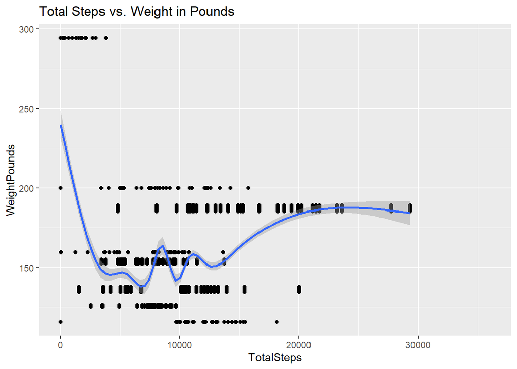

Let’s calculate the correlation coefficient now:

```
## [1] 0.2647917
```

## Conclusions

There are more observations of participants activity, steps, and distance covered, than observations about sleep hours and weight data, and there are more unique participants for activity than for sleep and weight. This is probably because the activity, steps, distance, and sleep hours data is automatically tracked and weight has to be entered manually. Because only few participants have logged their weight, users should be encouraged to enter their weight to fully benefit from Bellabeat’s product features.

No hydration data was collected, so the participants have not been using a smart hydration bottle, like the Bellabeat’s Spring water bottle. This opens the door for Bellabeat to start actively marketing their Spring bottle as this sets them apart from the competition. I also suggest using the users daily steps data along with the hydration data to adjust (and maybe push) the users daily hydration goal for the day based on their activity level.

Even though there is no relation between sleep hours per day and activity, promoting better sleep habits is likely very important for Bellabeat’s target customers, and therefore the sleep feature should be focused on more as informational or just encouragement to make sure the user gets enough sleep.

For users who want to track their weight, they should be encouraged logging their weight daily. This can be accomplished by piloting a smart scale that connect to the app.

## Recommendations:

- Promote all Bellabeat products by offering bundle deals, discounts, etc.
- Promote the Spring smart water bottle, as this sets the company apart from the competition.
- Start offering a smart scale to encourage weight logging, and to bundle with other products. This also sets the company apart from competition.
- Promote the Bellabeat membership by offering discounts when bundling with other products.
- Make it easy for all results to be shared with friends to encourage users to become more healthy.
- Enable alert notifications to encourage users to meet their goals for minutes of activity, calories burned per day, hours of sleep, and weight loss.
- Encourage users to sit less by alerting them to start moving after a certain period of non-activity.
- Promote better sleep habits by notifying users of their daily sleep hours.

## Works Cited:

Möbius, Arashnic. “FitBit Fitness Tracker Data”, *https://www.kaggle.com/arashnic/fitbit*, Kaggle.com, 16 December, 2016.

CDC, “Lifestyle Coach Facilitation Guide: Post-Core”, https://www.cdc.gov/diabetes/prevention/pdf/postcurriculum_session8.pdf.

Just Stand Org, “Sitting-Time Calculator: How Much Are You Sitting?”. https://www.juststand.org/the-tools/sitting-time-calculator/

CDC, “How Much Sleep Do I Need? Sleep and Sleep Disorders”, *https://www.cdc.gov/sleep/about_sleep/how_much_sleep.html*.

CDC, “Body Measurements”, *https://www.cdc.gov/nchs/fastats/body-measurements.htm*.

Medical News Today, “Body fat percentage charts for men and women”, *https://www.medicalnewstoday.com/articles/body-fat-percentage-chart*, June 23, 2020

Medical News Today. “Body fat percentage chart: Women, men, and calculations”, *https://www.medicalnewstoday.com*, Jun 23, 2020